# Project Python Foundations: FoodHub Data Analysis

## Countplot for Resturants names

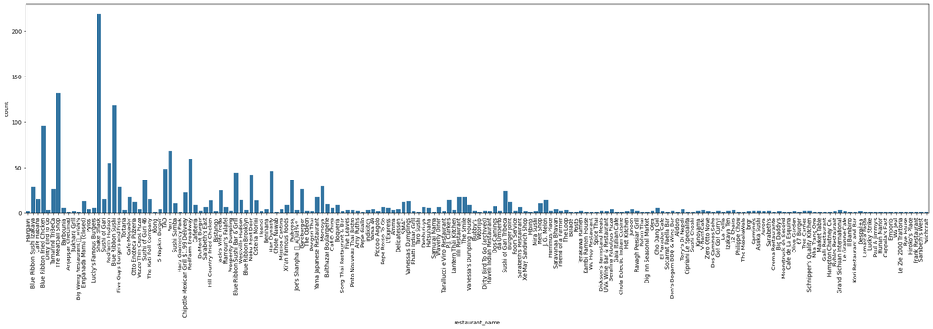

```python
# let us check the counts of resturants names.
plt.figure(figsize=(30,7))
sns.countplot(x=df['restaurant_name']);
plt.xticks(rotation=90);
```

- We can noticed that Shake Shack resturant has the highest numbers of orders.

## Barplot for cuisine types vs the cost during day of the week

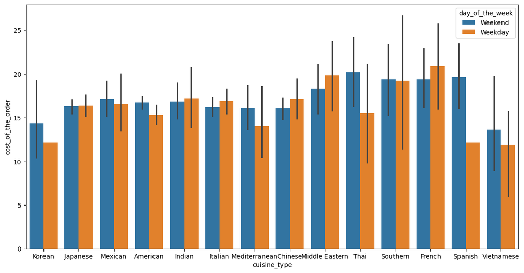

```python
# lets check the cost vs each cuisine_type
plt.figure(figsize=(14,7))
sns.barplot(x=df['cuisine_type'],y=df['cost_of_the_order'],hue=df['day_of_the_week'])
```

- we noticed that the French food has the highst cost in weekdays and Thai food has the highst one in weekend.

### **Question 7**: Which are the top 5 restaurants in terms of the number of orders received? [1 mark]

```python
# Write the code here
df['restaurant_name'].value_counts().head()
```

| restaurant_name | count |
| --- | --- |
| Shake Shack | 219 |
| The Meatball Shop | 132 |
| Blue Ribbon Sushi | 119 |
| Blue Ribbon Fried Chicken | 96 |
| Parm | 68 |

**dtype:** int64

#### Observations:

- "Shake Shack" has the heighest number of orders (219). Then "The Meatball Shop" has (132) orders.

### **Question 8**: Which is the most popular cuisine on weekends? [1 mark]

```python
# Write the code here
df[df['day_of_the_week']=='Weekend']['cuisine_type'].value_counts().head()
```

| cuisine_type | count |
| --- | --- |
| American | 415 |
| Japanese | 335 |
| Italian | 207 |
| Chinese | 163 |
| Mexican | 53 |

**dtype:** int64

#### Observations:

- The most popular in weekend is American food which is(415).

### **Question 9**: What percentage of the orders cost more than 20 dollars? [2 marks]

```python
# Write the code here
(df[df['cost_of_the_order']>20].shape[0]/df.shape[0])*100
```

```
29.24130663856691
```

#### Observations:

The percentsge of the orders that cost more than 20 dollars is 29.24%

### **Question 10**: What is the mean order delivery time? [1 mark]

```python
# We will use mean() function to calculate the mean value of the delivary time.
df['delivery_time'].mean()
```

```
24.161749209694417
```

#### Observations:

- The mean value of the dilvery timeis 24 minuts.

### **Question 11:** The company has decided to give 20% discount vouchers to the top 3 most frequent customers. Find the IDs of these customers and the number of orders they placed. [1 mark]

```python
# First lets find the customers.
Frequent_customers = df['customer_id'].value_counts().head(3)
Frequent_customers
```

| customer_id | count |
| --- | --- |
| 52832 | 13 |
| 47440 | 10 |
| 83287 | 9 |

**dtype:** int64

#### Observations:

- The most frequent customer has The ID (52832) and he placed 13 orders, Then (47440) with 10 orders and finally (83287) with 9 orders

### **Question 12**: Perform a multivariate analysis to explore relationships between the important variables in the dataset. (It is a good idea to explore relations between numerical variables as well as relations between numerical and categorical variables) [10 marks]

## Lets First Take the relation between The Rating amd Food Prepration time and between Rating and Delivary time and rating with cost of the order

### Rating vs Food perparation time

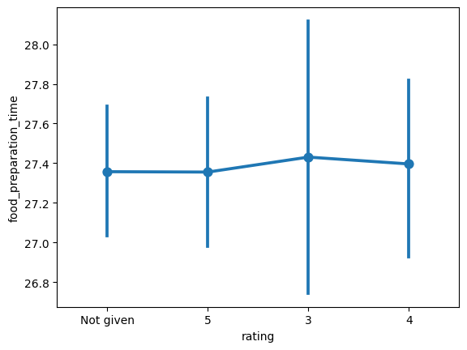

```python
sns.pointplot(x=df['rating'],y=df['food_preparation_time']) ;
```

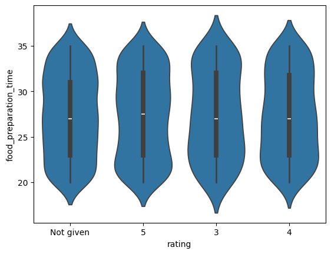

```python
sns.violinplot(x=df['rating'],y=df['food_preparation_time']);
```

### Rating vs Delivery time

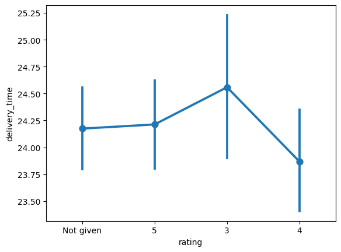

```python
sns.pointplot(x=df['rating'],y=df['delivery_time']);
```

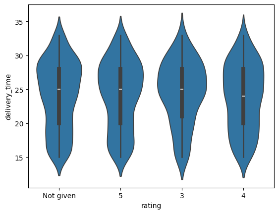

```python
sns.violinplot(x=df['rating'],y=df['delivery_time']);
```

### Rating vs Cost of the order

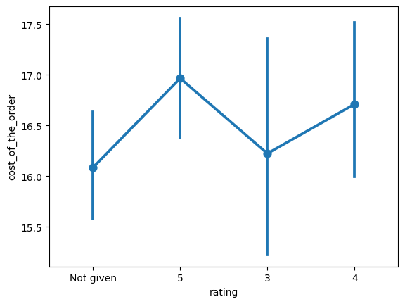

```python
sns.pointplot(x=df['rating'],y=df['cost_of_the_order']);
```

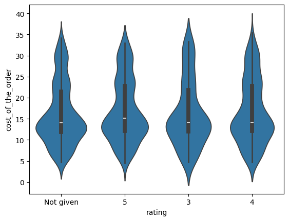

```python
sns.violinplot(x=df['rating'],y=df['cost_of_the_order']);
```

## Now lets use boxplot to find the relationship between the numerical and categorical data.

### Cost of the order during day of the week

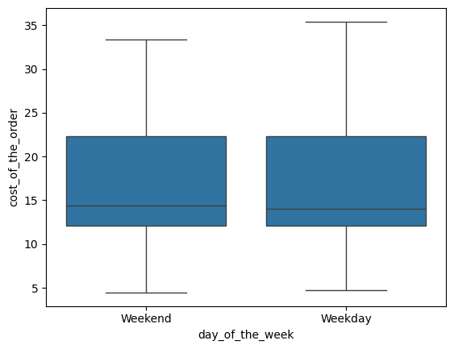

```python
sns.boxplot(x=df['day_of_the_week'],y=df['cost_of_the_order']);
```

### Cost of the order for each cuisine type

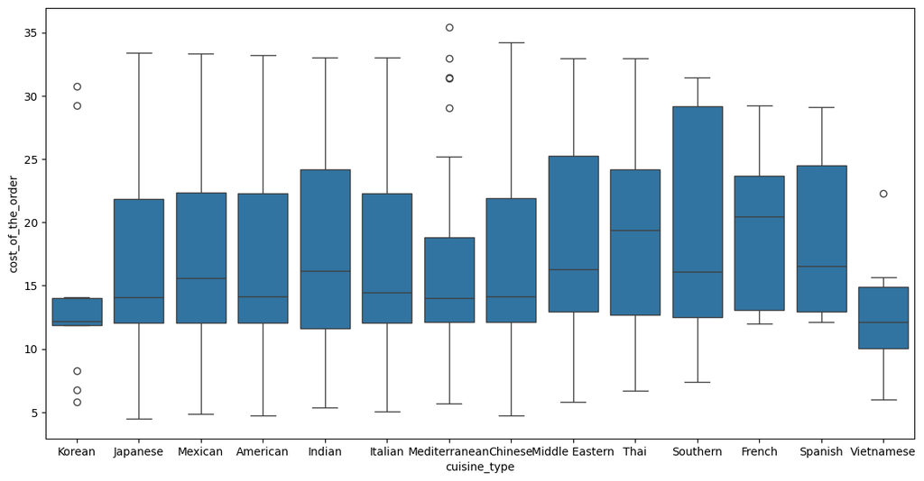

```python
plt.figure(figsize=(14,7))
sns.boxplot(x=df['cuisine_type'],y=df['cost_of_the_order']);
```

### Delivery time during day of the week

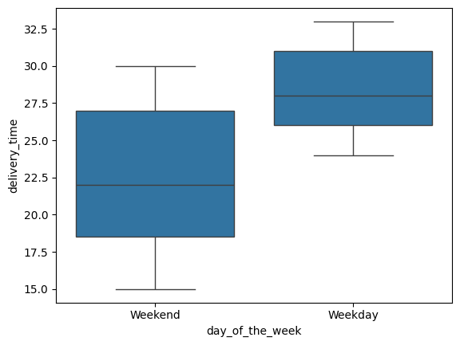

```python
sns.boxplot(x=df['day_of_the_week'],y=df['delivery_time']);
```

- We can notice that in weekday the delivery take more times than in weekend

### Food perparation time during day of the week

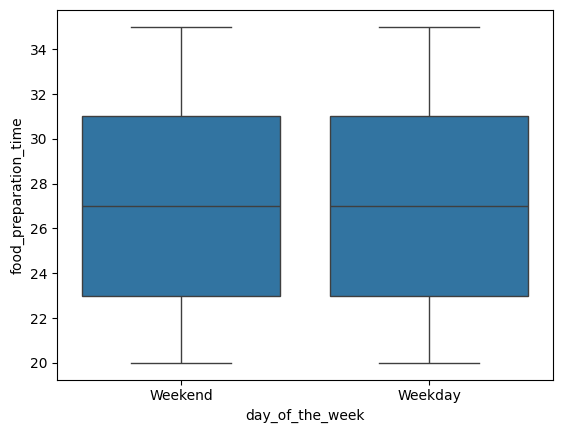

```python
sns.boxplot(x=df['day_of_the_week'],y=df['food_preparation_time']);
```

- we can consider them as symmetric

### The Cuisine type vs food preparation time during day of the week

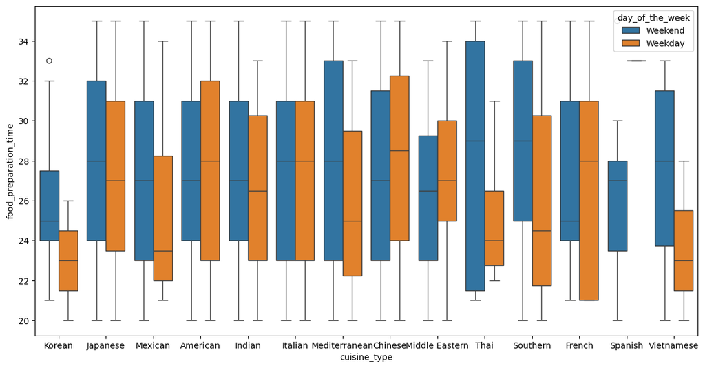

```python
plt.figure(figsize=(14,7))
sns.boxplot(x=df['cuisine_type'],y=df['food_preparation_time'],hue=df['day_of_the_week']);
```

## finally lets Plot the relationship between all the columns in the data set.

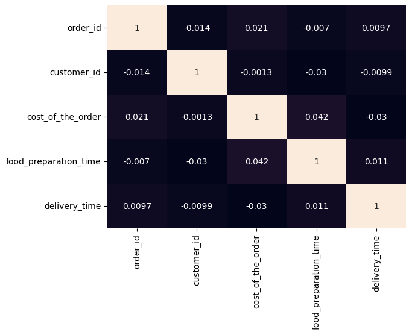

```python
sns.heatmap(df[['order_id','customer_id','cost_of_the_order','food_preparation_time','delivery_time']].corr(),annot=True,cbar=False);
```

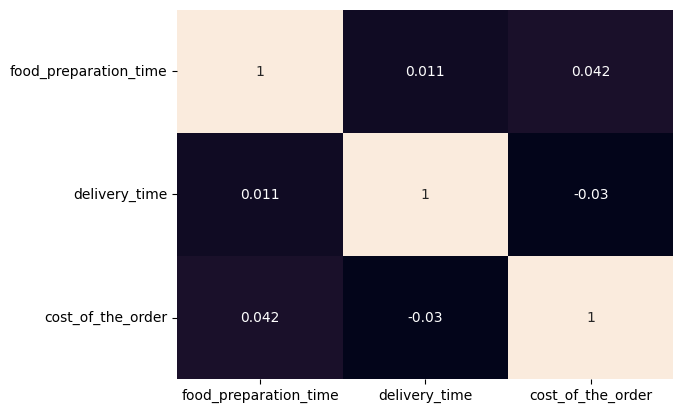

```python
# lets visualize the correlation only between preparation time, delivary time and the cost of the order
sns.heatmap(df[['food_preparation_time','delivery_time','cost_of_the_order']].corr(),annot=True,cbar=False);
```

- We noticed that the correlation is very poor, the highest correlation is 0.042.

### **Question 13:** The company wants to provide a promotional offer in the advertisement of the restaurants. The condition to get the offer is that the restaurants must have a rating count of more than 50 and the average rating should be greater than 4. Find the restaurants fulfilling the criteria to get the promotional offer. [3 marks]

```python
# first lets take the rating without "Not given" and change the data type to integer.
new_df =df[df['rating'] !='Not given'].copy()
new_df['rating'] = new_df['rating'].astype(int)
highest_rating = new_df.groupby('restaurant_name')['rating'].count().sort_values(ascending=False).reset_index()
#print(highest_rating.head())
#print('----------------------------------')
# the data which has the count rating>50
greater_than_50_df = highest_rating[highest_rating['rating']>50]
#print(greater_than_50_df.head())
#print('----------------------------------')
# lets find the mean rating
mean_df = new_df[new_df['restaurant_name'].isin(greater_than_50_df['restaurant_name'])].copy()
#print(mean_df.head())
#print('----------------------------------')
mean_rating = mean_df.groupby('restaurant_name')['rating'].mean().sort_values(ascending=False).reset_index()
#print(mean_rating.head())
mean_rating[mean_rating['rating']>4]
```

|  | restaurant_name | rating |
| --- | --- | --- |
| 0 | The Meatball Shop | 4.511905 |
| 1 | Blue Ribbon Fried Chicken | 4.328125 |
| 2 | Shake Shack | 4.278195 |
| 3 | Blue Ribbon Sushi | 4.219178 |

#### Observations:

- There are 4 resturants that have rating count greater than 50 and mean greater than 4 which are: {The Meatball shop, Blue Ribbon Fried Chicken,Shake shack, Blue Ribbon Sushi}

### **Question 14:** The company charges the restaurant 25% on the orders having cost greater than 20 dollars and 15% on the orders having cost greater than 5 dollars. Find the net revenue generated by the company across all orders. [3 marks]

```python
# we need to write statements for all the case using function to check all the case
def Revenue(cost):
  if cost>20:
    return cost*0.25
  elif cost>5:
    return cost*0.15
  else:
    return 0
df['net_revenue']=df['cost_of_the_order'].apply(Revenue)
df['net_revenue']
# Then we need to calculate the total revenue
Total_revenue = df['net_revenue'].sum()
print(Total_revenue, '$')
```

```
6166.303 $
```

#### Observations:

- The total net revenues is 6166.303 $.

### **Question 15:** The company wants to analyze the total time required to deliver the food. What percentage of orders take more than 60 minutes to get delivered from the time the order is placed? (The food has to be prepared and then delivered.) [2 marks]

```python
# first lets add new column for the totaltime preparation + delivery.
df['total_time'] = df['food_preparation_time'] + df['delivery_time']
df['total_time'].head()
# Then lets find the percentage of orders that take more than 60 mins.
order_60 = df[df['total_time']>60].shape[0]/df.shape[0]*100
order_60
```

```
10.537407797681771
```

#### Observations:

- The percentage of orders that take more than 60 mins is 10.537%.

### **Question 16:** The company wants to analyze the delivery time of the orders on weekdays and weekends. How does the mean delivery time vary during weekdays and weekends? [2 marks]

```python
df.groupby('day_of_the_week')['delivery_time'].mean()
```

[output not shown]

#### Observations:

- The mean delivery time in the weekend is 22.47.
- The mean delivery time in the weekday is 28.34.